# Treat Yo Self - An analysis of Parks and Recreation

Maude Elovitz & Julia Hartnett

**Now entering Pawnee, Indiana**

[figure not shown]

Parks and Recreation is the best television show to exist. If you haven’t seen it, this will hopefully give you a nice introduction to the show. We will be using some script data that we got from Kaggle containing the character speaking and lines of each episode.

Before doing any analysis with the data, we need to load some packages.

```r
library(tidyverse)
library(tidytext)
library(stringr)
library(ngram)
library(tidymodels)
```

We took the episode data and used a for loop to create the seasons. We then combined all the seasons into one data set to have all the lines of the entire series together.

```r
#season1
data = list()
for (i in 1:6){
  file_name = paste0("s1e0", i, ".csv")
  data[[i]] = read_csv(file_name)
  data[[i]]$season = 1
  data[[i]]$episode = i

}

season1_parks = as.data.frame(do.call(rbind, data))
write.csv(season1_parks, "season1_parks.csv", row.names = FALSE)

#season2
data = list()
for (i in 1:24){
  if (i %in% 1:9){
    file_name = paste0("s2e0", i, ".csv")
    data[[i]] = read_csv(file_name)
  }
  else{
    file_name = paste0("s2e", i, ".csv")
    data[[i]] = read_csv(file_name)
  }
  data[[i]]$season = 2
  data[[i]]$episode = i
}
season2_parks = as.data.frame(do.call(rbind, data))
write.csv(season2_parks, "season2_parks.csv", row.names = FALSE)

#season3
data = list()
for (i in 1:16){
  if (i %in% 1:9){
    file_name = paste0("s3e0", i, ".csv")
    data[[i]] = read_csv(file_name)
  }
  else{
    file_name = paste0("s3e", i, ".csv")
    data[[i]] = read_csv(file_name)
  }
  data[[i]]$season = 3
  data[[i]]$episode = i
}
season3_parks = as.data.frame(do.call(rbind, data))
write.csv(season3_parks, "season3_parks.csv", row.names = FALSE)

#season4
data = list()
for (i in 1:22){
  if (i %in% 1:9){
    file_name = paste0("s4e0", i, ".csv")
    data[[i]] = read_csv(file_name)
  }
  else{
    file_name = paste0("s4e", i, ".csv")
    data[[i]] = read_csv(file_name)
  }
  data[[i]]$season = 4
  data[[i]]$episode = i
}
season4_parks = as.data.frame(do.call(rbind, data))
write.csv(season4_parks, "season4_parks.csv", row.names = FALSE)

#season5
data = list()
for (i in 1:22){
  if (i %in% 1:9){
    file_name = paste0("s5e0", i, ".csv")
    data[[i]] = read_csv(file_name)
  }
  else{
    file_name = paste0("s5e", i, ".csv")
    data[[i]] = read_csv(file_name)
  }
  data[[i]]$season = 5
  data[[i]]$episode = i
}
season5_parks = as.data.frame(do.call(rbind, data))
write.csv(season5_parks, "season5_parks.csv", row.names = FALSE)

#season6
data = list()
for (i in 1:20){
  if (i %in% 1:9){
    file_name = paste0("s6e0", i, ".csv")
    data[[i]] = read_csv(file_name)
  }
  else{
    file_name = paste0("s6e", i, ".csv")
    data[[i]] = read_csv(file_name)
  }
  data[[i]]$season = 6
  data[[i]]$episode = i
}
season6_parks = as.data.frame(do.call(rbind, data))
write.csv(season6_parks, "season6_parks.csv", row.names = FALSE)

#season7
data = list()
for (i in 1:12){
  if (i %in% 1:9){
    file_name = paste0("s7e0", i, ".csv")
    data[[i]] = read_csv(file_name)
  }
  else{
    file_name = paste0("s7e", i, ".csv")
    data[[i]] = read_csv(file_name)
  }
  data[[i]]$season = 7
  data[[i]]$episode = i
}
season7_parks = as.data.frame(do.call(rbind, data))
write.csv(season7_parks, "season7_parks.csv", row.names = FALSE)

parks_script = rbind(season1_parks, season2_parks, season3_parks, season4_parks, season5_parks, season6_parks, season7_parks)
write.csv(parks_script, "parks_script.csv", row.names = FALSE)
```

**Who speaks the most in the show?** We were interested to see which character had the most lines throughout the entire course of the show. To find this, we filtered our data set containing all of the lines in the show to only include the lines from the main cast. Then we counted the number of lines per character and made a barplot. We used ‘fct_reorder’ to arrange the bars in descending order.

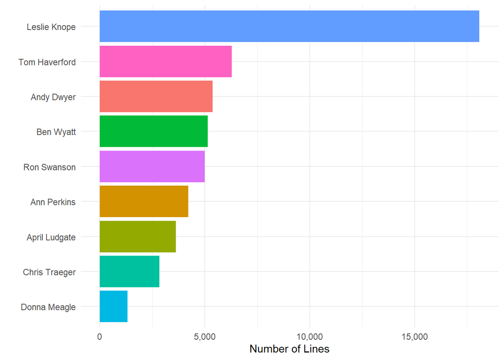

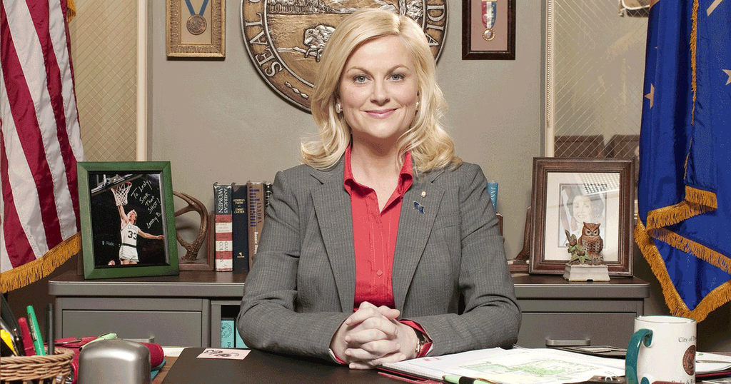

```r
parks_script %>%
  filter(Character %in% c("Leslie Knope", "Tom Haverford", "Ann Perkins", "Ron Swanson", "April Ludgate", "Andy Dwyer", "Ben Wyatt", "Chris Traeger", "Donna Meagle")) %>%
  count(Character, sort = TRUE) %>%
  ggplot(aes(x = fct_reorder(Character, n), y = n)) +
  geom_col(aes(fill = Character))+
  theme_minimal()+
  theme(legend.position = "none") +
  coord_flip() +
  labs(x = "", y = "Number of Lines") +
  scale_y_continuous(label = scales::comma)
```

Damn, Leslie has a lot of lines. She’s the main character of the show so that makes sense. But does she have the highest average words per line?

The first thing we had to do to find this is count the number of words per line. We did this by grouping by Line, season, and episode to keep each line on its own.

```r
parks_script = parks_script %>%
  group_by(Line, season, episode) %>%
  mutate(word_count = wordcount(Line))
```

Then we filtered for the same main characters as before and calculated their total word count and average word count.

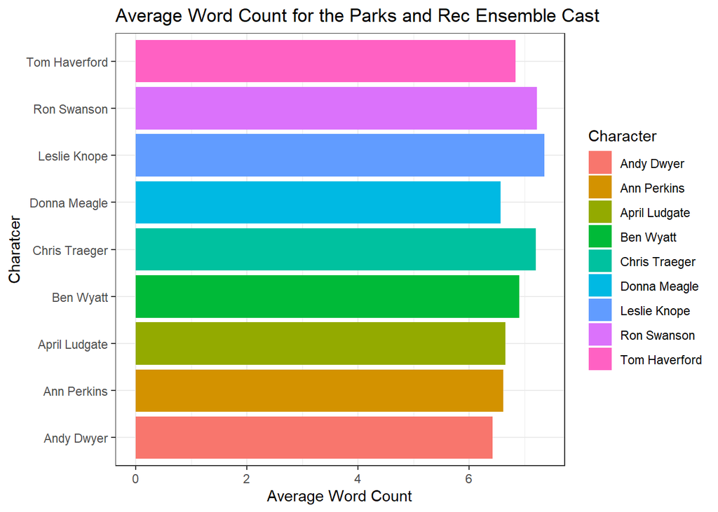

```r
parks_wordcount = parks_script %>%
  filter(Character %in% c("Leslie Knope", "Tom Haverford", "Ann Perkins", "Ron Swanson", "April Ludgate", "Andy Dwyer", "Ben Wyatt", "Chris Traeger", "Donna Meagle")) %>%
  group_by(Character) %>%
  summarize(total_word_count = sum(word_count),
            avg_word_count = mean(word_count))

ggplot(aes(x = Character, y = avg_word_count), data = parks_wordcount) +
  geom_col(aes(fill = Character)) +
  theme(legend.position = "none")+
  labs(x="Charatcer", y="Average Word Count", title = "Average Word Count for the Parks and Rec Ensemble Cast")+
  coord_flip()+
  theme_bw()
```

All of the regular ensemble cast members are fairly equal!!

**Are there any random characters with a high average word count??**

To find this, we left all of the characters in the data set and calculated their total and average word count.

```r
parks_wordcount_all = parks_script %>%
  group_by(Character) %>%
  summarize(total_word_count = sum(word_count),
            avg_word_count = mean(word_count)) %>%
  top_n(10, avg_word_count)

parks_wordcount_all
```

```
## # A tibble: 10 x 3
##    Character       total_word_count avg_word_count
##    <chr>                      <int>          <dbl>
##  1 Alyssa                        30           15
##  2 Derry Murbles                337           11.6
##  3 DJ Bluntz                     16           16
##  4 Edgar Covington               99           12.4
##  5 Elsa Clack                    49           12.2
##  6 Emcee                         24           12
##  7 Florence                      25           12.5
##  8 Kay Hanley                    58           19.3
##  9 Nick Newport                  66           13.2
## 10 Old Gus                       94           15.7
```

It appears that there are a lot of minor characters with higher average word counts than our main cast! This is interesting, especially since we, hard-core Parks and Rec fans, had to google who Alyssa is.

**Can we predict which character is speaking from the sentiment of the line?**

First used a pipeline to calculate the sentiment score for each line in the show and filter to only include the main cast members. We then created the training and testing sets for the model. We used these to build a decision tree predicting character from sentiment score. We obtained the accuract prediction metric for our model.

```r
parks_sentiment = parks_script %>%
  group_by(season, episode) %>%
  mutate(linenum = row_number()) %>%
  ungroup() %>%
  group_by(season, episode, linenum) %>%
  unnest_tokens(word, Line) %>%
  anti_join(stop_words) %>%
  inner_join(get_sentiments("bing")) %>%
  select(Character, linenum, sentiment)%>%
  count(sentiment, Character) %>%
  spread(sentiment, n) %>%
  replace_na(list(negative = 0, positive = 0)) %>%
  mutate(score = positive - negative) %>%
  ungroup() %>%
  filter(Character %in% c("Leslie Knope", "Tom Haverford", "Ann Perkins", "Ron Swanson", "April Ludgate", "Andy Dwyer", "Ben Wyatt", "Chris Traeger", "Donna Meagle"))

set.seed(12)
parks_sentiment_split = initial_split(parks_sentiment)
parks_sentiment_train = training(parks_sentiment_split)
parks_sentiment_test = testing(parks_sentiment_split)

parks_sentiment_tree_fit =
  decision_tree() %>%
  set_engine(engine = "rpart") %>%
  set_mode(mode = "classification") %>%
  fit(factor(Character) ~ score, data = parks_sentiment_train)

parks_sentiment_pred = parks_sentiment_tree_fit %>%
  predict(new_data = parks_sentiment_test)


parks_sentiment_test %>%
  mutate(pred_char = parks_sentiment_pred$.pred_class) %>%
  accuracy(estimate = pred_char, truth = factor(Character))
```

```
## # A tibble: 1 x 3
##   .metric  .estimator .estimate
##   <chr>    <chr>          <dbl>
## 1 accuracy multiclass     0.343
```

That’s a very low accuracy measure.. Why?

```r
parks_sentiment %>%
  group_by(Character) %>%
  summarize(avg_score = mean(score))
```

```
## # A tibble: 9 x 2
##   Character     avg_score
##   <chr>             <dbl>
## 1 Andy Dwyer      0.0308
## 2 Ann Perkins    -0.00198
## 3 April Ludgate  -0.163
## 4 Ben Wyatt       0.0478
## 5 Chris Traeger   0.165
## 6 Donna Meagle   -0.140
## 7 Leslie Knope    0.00427
## 8 Ron Swanson    -0.109
## 9 Tom Haverford  -0.0138
```

All of the main characters have around the same average sentiment score, which could make it hard for the model to predict exactly who is talking.

Leslie and Ron are two very different characters, what would happen if we built a model using just their lines?

```r
parks_sentiment_leslieandron = parks_sentiment %>%
  filter(Character %in% c("Leslie Knope", "Ron Swanson"))

set.seed(12)
parks_leslieandron_split = initial_split(parks_sentiment_leslieandron)
parks_leslieandron_train = training(parks_leslieandron_split)
parks_leslieandron_test = testing(parks_leslieandron_split)

parks_leslieandron_tree_fit =
  decision_tree() %>%
  set_engine(engine = "rpart") %>%
  set_mode(mode = "classification") %>%
  fit(factor(Character) ~ score, data = parks_leslieandron_train)

parks_leslieandron_pred = parks_leslieandron_tree_fit %>%
  predict(new_data = parks_leslieandron_test)


parks_leslieandron_test %>%
  mutate(pred_char = parks_leslieandron_pred$.pred_class) %>%
  accuracy(estimate = pred_char, truth = factor(Character))
```

```
## # A tibble: 1 x 3
##   .metric  .estimator .estimate
##   <chr>    <chr>          <dbl>
## 1 accuracy binary         0.774
```

This model has a much higher accuracy, which makes sense. It is much easier to predict that a line such as “Government is useless” would be Ron Swanson than Leslie Knope, who often talks about friendship and waffles.

[figure not shown]